# Notebook 05: Perform DE Analysis

Author

Shirshak Aryal

Published

July 3, 2026

Perform **Differential Expression (DE) Analysis** on the **filtered** **`unstranded` raw counts matrix**. The primary purpose of DE analysis in this project is to **identify the genes that are genuinely expressed differently in statistically significant amounts between the Proneural and Mesenchymal samples**.

The DE analysis will consider Proneural samples as the basis of comparison for Mesenchymal samples. The steps are as follows:

- **Setup**: **Justify** the choice of **DE analysis approaches** using the **mean-variance plot**, confirming **overdispersion** in the data.
- **DE analyses**: Perform DE analysis with **`DESeq2`** (**primary** approach) as well as **`EdgeR`** (**confirmatory** approach) to create these lists:
  - Genes **upregulated** in Mesenchymal samples as per **`DESeq2`**
  - Genes **downregulated** in Mesenchymal samples as per **`DESeq2`**
  - Genes **upregulated** in Mesenchymal samples as per **`EdgeR`**
  - Genes **downregulated** in Mesenchymal samples as per **`EdgeR`**
- **Consensus lists**: **Retain** only those genes that are considered **upregulated by both approaches**, as well as those that are considered **downregulated by both approaches**. These are the most reliable lists to be used in pathway enrichment analysis.

**NOTE**: **All genes** common in each pair of **up/downregulated lists** will be retained as the consensus lists, not just the top `n` genes.

## 1. Import Libraries

```r
library(tidyverse)        # data manipulation and visualisation
library(patchwork)        # combine multiple ggplot2 plots into one canvas
library(pheatmap)         # colorful heatmaps
library(DESeq2)           # primary differential expression analysis using negative binomial model with empirical Bayes shrinkage
library(edgeR)            # confirmatory differential expression analysis using negative binomial model
library(ggrepel)          # non-overlapping gene name labels for individual data points in plots
library(org.Hs.eg.db)     # human gene annotation database
library(clusterProfiler)  # gene ID conversion (i.e. for bitr() function)
library(ggvenn)           # venn diagrams for visualising gene list overlaps


cat("\nLibraries loaded successfully\n")
```

```
Libraries loaded successfully
```

```r
cat("tidyverse version:         ", as.character(packageVersion("tidyverse")), "\n")
```

```
tidyverse version:          2.0.0
```

```r
cat("DESeq2 version:            ", as.character(packageVersion("DESeq2")), "\n")
```

```
DESeq2 version:             1.50.2
```

```r
cat("edgeR version:             ", as.character(packageVersion("edgeR")), "\n")
```

```
edgeR version:              4.8.2
```

```r
cat("ggrepel version:           ", as.character(packageVersion("ggrepel")), "\n")
```

```
ggrepel version:            0.9.8
```

```r
cat("org.Hs.eg.db version:      ", as.character(packageVersion("org.Hs.eg.db")), "\n")
```

```
org.Hs.eg.db version:       3.22.0
```

```r
cat("clusterProfiler version:   ", as.character(packageVersion("clusterProfiler")), "\n")
```

```
clusterProfiler version:    4.18.4
```

```r
cat("ggvenn version:            ", as.character(packageVersion("ggvenn")), "\n")
```

```
ggvenn version:             0.1.19
```

## 2. Load Data

### 2.1. Load Filtered Counts Matrix

```r
filtered_counts_matrix <- readRDS("../01_data/02_processed/04_filtered_counts_matrix.rds")
cat("Filtered counts matrix loaded:", nrow(filtered_counts_matrix), "genes x", ncol(filtered_counts_matrix), "samples\n\n")
```

```
Filtered counts matrix loaded: 16164 genes x 180 samples
```

```r
filtered_counts_matrix[1:3, 1:3]
```

```
                   TCGA-06-0166-01A-01R-A96R-41 TCGA-06-5859-01A-01R-1849-01
ENSG00000000003.15                         2149                         6236
ENSG00000000005.6                             7                          124
ENSG00000000419.13                          945                         1491
                   TCGA-06-5859-01A-01R-A96S-41
ENSG00000000003.15                         5577
ENSG00000000005.6                           136
ENSG00000000419.13                         1251
```

### 2.2. Load Filtered Tumor Subtype Information

```r
tumor_subtype_info <- readRDS("../01_data/02_processed/05_filtered_tumor_subtype_info.rds")

cat("Filtered tumor subtype info loaded:", nrow(tumor_subtype_info), "samples\n")
```

```
Filtered tumor subtype info loaded: 180 samples
```

```r
tumor_subtype_info %>%
  as.data.frame() %>%
  dplyr::select(paper_Transcriptome.Subtype) %>%
  head(5) %>%
  knitr::kable()
```

|  | paper_Transcriptome.Subtype |
| --- | --- |
| TCGA-06-0166-01A-01R-A96R-41 | PN |
| TCGA-06-5859-01A-01R-1849-01 | ME |
| TCGA-06-5859-01A-01R-A96S-41 | ME |
| TCGA-14-4157-01A-01R-A96U-41 | PN |
| TCGA-06-5416-01A-01R-1849-01 | PN |

### 2.3. Load Filtered Gene Metadata

```r
gene_metadata <- readRDS("../01_data/02_processed/06_filtered_gene_metadata.rds")
cat("Filtered gene metadata loaded:", nrow(gene_metadata), "genes\n")
```

```
Filtered gene metadata loaded: 16164 genes
```

```r
gene_metadata[1:5, 1:8] %>% as.data.frame() %>% knitr::kable()
```

|  | source | type | score | phase | gene_id | gene_type | gene_name | level |
| --- | --- | --- | --- | --- | --- | --- | --- | --- |
| ENSG00000000003.15 | HAVANA | gene | NA | NA | ENSG00000000003.15 | protein_coding | TSPAN6 | 2 |
| ENSG00000000005.6 | HAVANA | gene | NA | NA | ENSG00000000005.6 | protein_coding | TNMD | 2 |
| ENSG00000000419.13 | HAVANA | gene | NA | NA | ENSG00000000419.13 | protein_coding | DPM1 | 2 |
| ENSG00000000457.14 | HAVANA | gene | NA | NA | ENSG00000000457.14 | protein_coding | SCYL3 | 2 |
| ENSG00000000460.17 | HAVANA | gene | NA | NA | ENSG00000000460.17 | protein_coding | C1orf112 | 2 |

## 3. Perform DE Analysis

### 3.1. Create Mean-Variance Plot

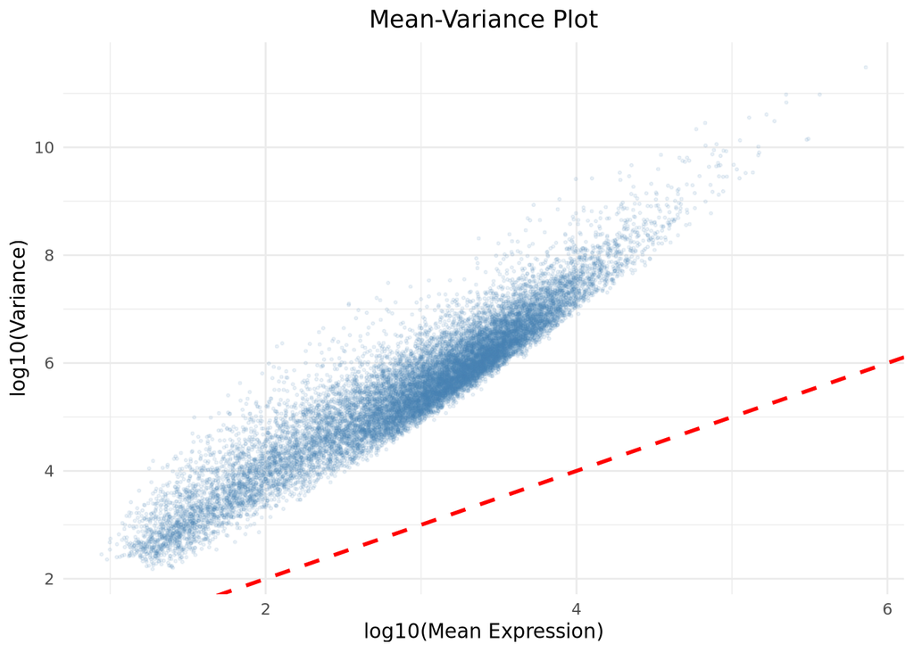

```r
# calculate per-gene mean and variance across all samples
gene_means     <- rowMeans(filtered_counts_matrix)
gene_variances <- rowVars(filtered_counts_matrix)


mv_plot_data    <- data.frame(
                     mean     = gene_means,
                     variance = gene_variances
                   )
mv_plot_mapping <- aes(x = log10(mean), y = log10(variance))
mv_plot_labels  <- labs(
                     title = "Mean-Variance Plot",
                     x     = "log10(Mean Expression)",
                     y     = "log10(Variance)"
                   )

mv_plot <- ggplot(mv_plot_data, mv_plot_mapping) +  # means and variances

             # point plot
             geom_point(
             alpha = 0.1,
             size = 0.5,
             colour = "steelblue"
           ) +

           # variance=mean line (poisson expectation)
           geom_abline(
             slope = 1,
             intercept = 0,
             colour = "red",
             linetype = "dashed",
             linewidth = 1
           ) +

           # labels
           mv_plot_labels +

           # themes
           theme_minimal() +
           theme(plot.title = element_text(hjust = 0.5))

mv_plot
```

The mean-variance plot shows that a**ll genes have variance substantially exceeding their mean** expression (all points **above the red Poisson expectation line** where variance = mean). The **gap** between **observed** variance and **Poisson** expectation **widens** with increasing expression, consistent with the **overdispersion pattern** modeled by the **negative binomial distribution**. This confirms that **`DESeq2` and `EdgeR`**, both of which use negative binomial modeling, are the **appropriate** tools for DE analysis **on this dataset**.

### 3.2. Perform DE Analysis With `DESeq2`

#### 3.2.1. Create `DESeq2` Object

```r
# create sample metadata dataframe with subtype as the grouping factor
col_data <- data.frame(
               subtype   = factor(
                             tumor_subtype_info$paper_Transcriptome.Subtype,
                             levels = c("PN", "ME")  # PN as reference level
                           ),
               row.names = rownames(tumor_subtype_info)
             )

# create DESeq2 object
dds <- DESeqDataSetFromMatrix(
  countData = filtered_counts_matrix,
  colData   = col_data,
  design    = ~ subtype  # compare by subtype
)

cat("DESeq2 object created\n")
```

```
DESeq2 object created
```

```r
cat("Genes:", nrow(dds), "\n")
```

```
Genes: 16164
```

```r
cat("Samples:", ncol(dds), "\n")
```

```
Samples: 180
```

```r
cat("Reference level:", levels(col_data$subtype)[1], "\n")
```

```
Reference level: PN
```

#### 3.2.2. Run `DESeq2`

By default, `DESeq2` always runs the **Wald test**, i.e. it calculates the **Wald statistic**.

Wald Statistic is simply the **standardized `log2FC`,** scaled by the **standard error of `log2FC`.** That is:

- **`Wald statistic = log2FC/lfcSE`**

It acts as a **signal-to-noise ratio**, where the **estimated `log2FC`** represents the **biological signal** of **difference in expression levels** and the **`log2FC` standard error (i.e. `lfcSE`)** represents the **background noise**.

```r
dds <- DESeq(dds)  # implicitly runs: DESeq(dds, test="Wald")

cat("DESeq2 analysis complete\n")
```

```
DESeq2 analysis complete
```

#### 3.2.3. Extract `DESeq2` Results

```r
# extract results with ME vs PN comparison
deseq2_results <- results(
  dds,
  contrast      = c("subtype", "ME", "PN"),  # ME vs PN, positive LFC = higher in ME
  alpha         = 0.05                       # significance threshold
)

cat("DESeq2 results extracted\n")
```

```
DESeq2 results extracted
```

```r
cat("Total genes tested:", nrow(deseq2_results), "\n")
```

```
Total genes tested: 16164
```

```r
cat("Significant genes (padj < 0.05):", sum(deseq2_results$padj < 0.05, na.rm = TRUE), "\n")
```

```
Significant genes (padj < 0.05): 10636
```

#### 3.2.4. Filter `DESeq2` Results

Genes are **filtered** to retain only those with a **statistically significant adjusted p-value (`padj < 0.05`)** AND a **biologically meaningful fold change (`|log2FC| > 1`, i.e. at least 2-fold difference in expression)**. The **`padj` threshold** **controls** **false discovery rate**, while the **`log2FC` threshold** **removes** genes that are statistically **significant but too small in effect size** to be biologically meaningful.

Results are then split into **upregulated** and **downregulated** gene lists based on the **direction of the fold change.**

```r
# apply log2 fold change threshold on top of adjusted p-value
deseq2_sig <- as.data.frame(deseq2_results) %>%
              filter(padj < 0.05, abs(log2FoldChange) > 1)

# split into upregulated and downregulated in ME vs PN
deseq2_up   <- deseq2_sig %>% filter(log2FoldChange > 0) %>% arrange(desc(log2FoldChange))
deseq2_down <- deseq2_sig %>% filter(log2FoldChange < 0) %>% arrange(log2FoldChange)

cat("Genes passing padj < 0.05 AND |log2FC| > 1:\n")
```

```
Genes passing padj < 0.05 AND |log2FC| > 1:
```

```r
cat("Upregulated in ME:  ", nrow(deseq2_up), "\n")
```

```
Upregulated in ME:   1553
```

```r
cat("Downregulated in ME:", nrow(deseq2_down), "\n")
```

```
Downregulated in ME: 1163
```

#### 3.2.5. Create `DESeq2` Volcano Plot

##### 3.2.5.1. Shrink `DESeq2` Log Fold Changes

**Raw log fold changes** from DESeq2 can be **unreliable** for **lowly expressed genes**. **Small count** **differences** produce **large but noisy LFC estimates**. LFC shrinkage using the `**`apeglm`** **method** pulls these **unreliable estimates toward zero** while leaving **well-expressed genes with reliable estimates** largely unaffected.

Shrunken LFC values are used for **visualization (volcano plot)** and **GSEA ranking** only. The **significance filtering** above **used raw LFC values**, which is **standard** practice.

```r
deseq2_results_shrunk <- lfcShrink(
  dds,
  coef      = "subtype_ME_vs_PN",  # coefficient name from DESeq2 model
  type      = "apeglm"             # apeglm shrinkage method
)

cat("LFC shrinkage applied\n")
```

```
LFC shrinkage applied
```

```r
cat("Method: apeglm\n")
```

```
Method: apeglm
```

##### 3.2.5.2. Create `DESeq2` Volcano Plot

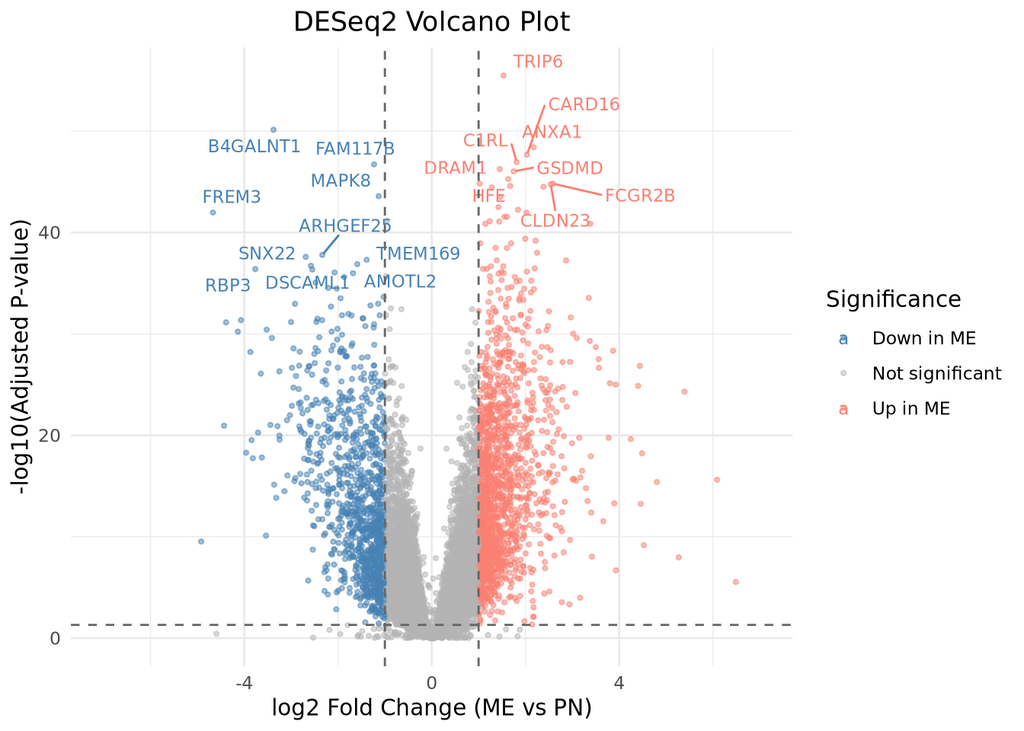

```r
# prepare data for volcano plot using shrunken LFC
deseq2_volcano_data <- as.data.frame(deseq2_results_shrunk) %>%
                       rownames_to_column("ensembl_id") %>%
                       filter(!is.na(padj)) %>%
                       mutate(
                         ensembl_id_clean = gsub("\\..*", "", ensembl_id),        # strip version numbers from ensembl IDs
                         significance = case_when(                                # classify genes by significance and direction
                           padj < 0.05 & log2FoldChange >  1 ~ "Up in ME",
                           padj < 0.05 & log2FoldChange < -1 ~ "Down in ME",
                           TRUE                              ~ "Not significant"
                         )
                      )

# map ensembl IDs to gene symbols for labels
deseq2_symbol_map <- bitr(
  deseq2_volcano_data$ensembl_id_clean,
  fromType = "ENSEMBL",
  toType   = "SYMBOL",
  OrgDb    = org.Hs.eg.db
)

deseq2_volcano_data <- deseq2_volcano_data %>%
                       left_join(deseq2_symbol_map, by = c("ensembl_id_clean" = "ENSEMBL"))

# top genes to label
deseq2_top_genes <- bind_rows(
  deseq2_volcano_data %>% filter(significance == "Up in ME") %>% arrange(padj) %>% head(10),
  deseq2_volcano_data %>% filter(significance == "Down in ME") %>% arrange(padj) %>% head(10)
)

# plot
deseq2_volcano_mapping <- aes(
                            x      = log2FoldChange,
                            y      = -log10(padj),
                            colour = significance
                   )
deseq2_volcano_labels  <- labs(
                            title  = "DESeq2 Volcano Plot",
                            x      = "log2 Fold Change (ME vs PN)",
                            y      = "-log10(Adjusted P-value)",
                            colour = "Significance"
                          )

deseq2_volcano_plot <- ggplot(deseq2_volcano_data, deseq2_volcano_mapping) +  # data

                       # point plot
                       geom_point(alpha = 0.5, size = 0.8) +

                       # ensure non-overlapping labels
                       geom_text_repel(
                         data        = deseq2_top_genes,
                         aes(label   = SYMBOL),
                         size        = 3,
                         max.overlaps = 20
                       ) +

                       # custom scale colors
                       scale_colour_manual(
                         values = c(
                           "Up in ME"        = "salmon",
                           "Down in ME"      = "steelblue",
                           "Not significant" = "grey70"
                         )
                       ) +

                       # log2FC threshold lines (vertical, at log2FC=-1 and lof2FC=+1)
                       geom_vline(xintercept = c(-1, 1), linetype = "dashed", colour = "grey40") +

                       # padj significance thresnhold line (horizontal)
                       geom_hline(yintercept = -log10(0.05), linetype = "dashed", colour = "grey40") +

                       # gene name labels
                       deseq2_volcano_labels +

                       # custom adjustments
                       theme_minimal() +
                       coord_cartesian(xlim = c(-7, 7)) +
                       theme(plot.title = element_text(hjust = 0.5))

deseq2_volcano_plot
```

The volcano plot shows genes **significantly upregulated in Mesenchymal (salmon, right)** and **downregulated in Mesenchymal/upregulated in Proneural (blue, left)**, with **dashed lines** marking the **significance (padj < 0.05) and fold change (|log2FC| > 1) thresholds.**

### 3.3. Perform DE Analysis With `EdgeR`

#### 3.3.1. Create TMM-Normalized `DGEList` Object

```r
# create DGEList object
dge <- DGEList(
         counts  = filtered_counts_matrix,
         group   = factor(
                      tumor_subtype_info$paper_Transcriptome.Subtype,
                      levels = c("PN", "ME")  # PN as reference
                    )
       )

# TMM normalisation
dge <- calcNormFactors(dge, method = "TMM")

cat("EdgeR DGEList object created\n")
```

```
EdgeR DGEList object created
```

```r
cat("Genes:", nrow(dge), "\n")
```

```
Genes: 16164
```

```r
cat("Samples:", ncol(dge), "\n")
```

```
Samples: 180
```

```r
cat("Normalisation method: TMM\n")
```

```
Normalisation method: TMM
```

#### 3.3.2. Run `EdgeR`

By default, `EdgeR` always runs the **F-test**, i.e. it calculates the **F-statistic**.

Mathematically, the F-statistic is as follows:

- **`F-statistic = (Likelihood Ratio Deviance) / (Quasi-Likelihood Dispersion)`**

Here:

- **Likelihood Ratio Deviance** quantifies how much better the data is explained when **PN and ME are allowed to have different average expression values**, compared to **forcing** both subtypes to share **one single average**. A **large deviance** means **treating them separately** explains the observed expression values **much better** than treating them as one group.
- Quasi-Likelihood Dispersion is the **gene’s estimated variability beyond what the negative binomial distribution alone predicts**. It is essentially how noisy this specific gene’s measurements are.

So, the F-statistic acts as a **signal-to-noise ratio**, where the Likelihood Ratio Deviance represents **how much PN and ME genuinely differ** (the **signal**), and the Quasi-Likelihood Dispersion represents the **gene’s inherent noisiness.**

```r
# design matrix with PN as reference
design <- model.matrix(~ group, data = dge$samples)

# estimate dispersions
dge <- estimateDisp(dge, design)

# fit negative binomial GLM
fit <- glmQLFit(dge, design)

# likelihood ratio test ME vs PN
edger_results <- glmQLFTest(fit, coef = 2)

cat("EdgeR analysis complete\n")
```

```
EdgeR analysis complete
```

#### 3.3.3. Extract `EdgeR` Results

```r
# extract results table
edger_results_table <- topTags(edger_results, n = Inf)$table

cat("EdgeR results extracted\n")
```

```
EdgeR results extracted
```

```r
cat("Total genes tested:", nrow(edger_results_table), "\n")
```

```
Total genes tested: 16164
```

```r
cat("Significant genes (FDR < 0.05):", sum(edger_results_table$FDR < 0.05), "\n")
```

```
Significant genes (FDR < 0.05): 10714
```

#### 3.3.4. Filter `EdgeR` Results

Genes are **filtered** to retain only those with a **statistically significant adjusted p-value (`padj < 0.05`)** AND a **biologically meaningful fold change (`|log2FC| > 1`, i.e. at least 2-fold difference in expression)**. The **`padj` threshold** **controls** **false discovery rate**, while the **`log2FC` threshold** **removes** genes that are statistically **significant but too small in effect size** to be biologically meaningful.

Results are then split into **upregulated** and **downregulated** gene lists based on the **direction of the fold change.**

```r
# apply log fold change threshold on top of FDR
edger_sig <- edger_results_table %>%
             filter(FDR < 0.05, abs(logFC) > 1)

# split into upregulated and downregulated in ME vs PN
edger_up   <- edger_sig %>% filter(logFC > 0) %>% arrange(desc(logFC))
edger_down <- edger_sig %>% filter(logFC < 0) %>% arrange(logFC)

cat("Genes passing FDR < 0.05 AND |logFC| > 1:\n")
```

```
Genes passing FDR < 0.05 AND |logFC| > 1:
```

```r
cat("Upregulated in ME:  ", nrow(edger_up), "\n")
```

```
Upregulated in ME:   1587
```

```r
cat("Downregulated in ME:", nrow(edger_down), "\n")
```

```
Downregulated in ME: 1162
```

#### 3.3.5. Create `EdgeR` Volcano Plot

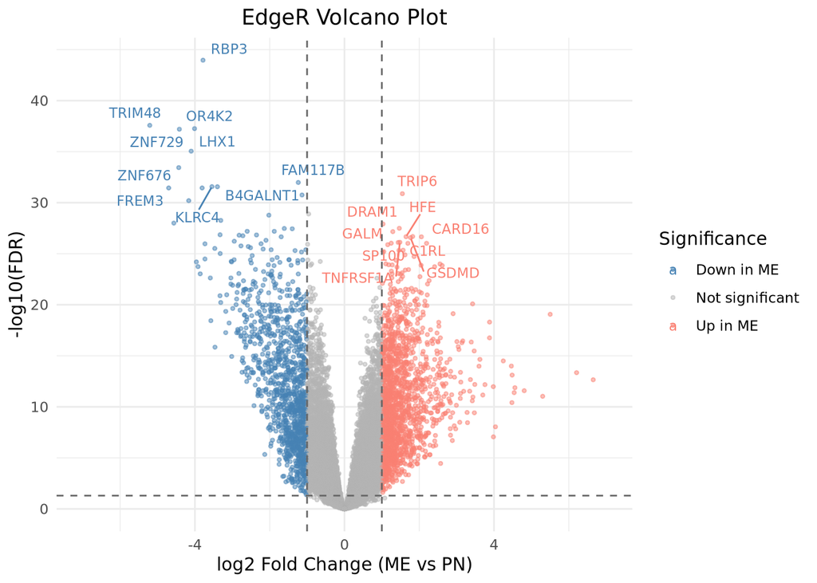

```r
# prepare data for volcano plot
edger_volcano_data <- edger_results_table %>%
                      rownames_to_column("ensembl_id") %>%
                      filter(!is.na(FDR)) %>%
                      mutate(
                        ensembl_id_clean = gsub("\\..*", "", ensembl_id),
                        significance     = case_when(
                          FDR < 0.05 & logFC >  1 ~ "Up in ME",
                          FDR < 0.05 & logFC < -1 ~ "Down in ME",
                          TRUE                     ~ "Not significant"
                        )
                      )

# map ensembl IDs to gene symbols
edger_symbol_map <- bitr(
  edger_volcano_data$ensembl_id_clean,
  fromType = "ENSEMBL",
  toType   = "SYMBOL",
  OrgDb    = org.Hs.eg.db
)

edger_volcano_data <- edger_volcano_data %>%
                      left_join(edger_symbol_map, by = c("ensembl_id_clean" = "ENSEMBL"))

# top genes to label
edger_top_genes <- bind_rows(
  edger_volcano_data %>% filter(significance == "Up in ME") %>% arrange(FDR) %>% head(10),
  edger_volcano_data %>% filter(significance == "Down in ME") %>% arrange(FDR) %>% head(10)
)

# plot
edger_volcano_mapping <- aes(
                           x      = logFC,
                           y      = -log10(FDR),
                           colour = significance
                         )
edger_volcano_labels  <- labs(
                           title  = "EdgeR Volcano Plot",
                           x      = "log2 Fold Change (ME vs PN)",
                           y      = "-log10(FDR)",
                           colour = "Significance"
                         )

edger_volcano_plot <- ggplot(edger_volcano_data, edger_volcano_mapping) +  # data

                      # point plot
                      geom_point(alpha = 0.5, size = 0.8) +

                      # ensure non-overlapping labels
                      geom_text_repel(
                        data         = edger_top_genes,
                        aes(label    = SYMBOL),
                        size         = 3,
                        max.overlaps = 20
                      ) +

                      # custom scale colors
                      scale_colour_manual(
                        values = c(
                          "Up in ME"        = "salmon",
                          "Down in ME"      = "steelblue",
                          "Not significant" = "grey70"
                        )
                      ) +

                      # log2FC threshold lines (vertical, at log2FC=-1 and lof2FC=+1)
                      geom_vline(xintercept = c(-1, 1), linetype = "dashed", colour = "grey40") +

                      # padj significance thresnhold line (horizontal)
                      geom_hline(yintercept = -log10(0.05), linetype = "dashed", colour = "grey40") +

                      # gene name labels
                      edger_volcano_labels +

                      # custom adjustments
                      theme_minimal() +
                      coord_cartesian(xlim = c(-7, 7)) +
                      theme(plot.title = element_text(hjust = 0.5))

edger_volcano_plot
```

### 3.4. Compare `DESeq2` And `EdgeR` Results

#### 3.4.1. Combine Volcano Plots

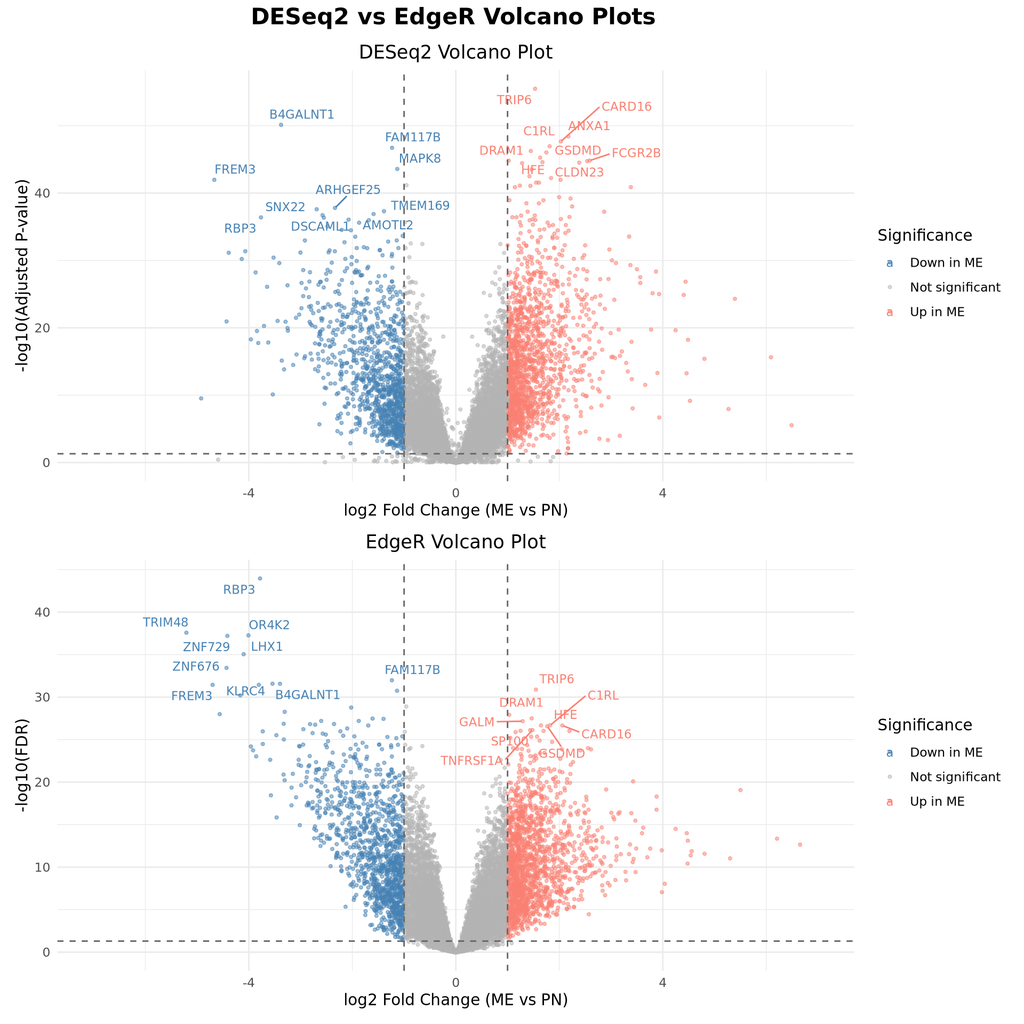

```r
combined_volcano_plot <- (deseq2_volcano_plot) /
                         (edger_volcano_plot) +
                         plot_annotation(
                           title = "DESeq2 vs EdgeR Volcano Plots",
                           theme = theme(
                                     plot.title = element_text(
                                                    hjust = 0.4,
                                                    size = 16,
                                                    face = "bold"
                                                  )
                                   )
                         )

combined_volcano_plot
```

The volcano plots show **DESeq2 (top) and EdgeR (bottom)** results side by side on matching x-axis scales.

- Genes **upregulated in ME (salmon, right)** include TRIP6, CARD16, ANXA1, GSDMD, FCGR2B, HFE: **immune/inflammatory genes** consistent with the **Mesenchymal subtype**.
- Genes **downregulated in ME (blue, left)** include B4GALNT1, FREM3, FAM117B, RBP3: **neural/brain-associated genes** consistent with the **Proneural subtype**.

The **substantial agreement** in labeled genes **between the two tools**, for instance genes like B4GALNT1, FREM3, RBP3, TRIP6, CARD16, HFE, GSDMD, C1RL, DRAM1 appearing as **top hits in both**, previews the high consensus overlap quantified **below in the venn diagrams.**

#### 3.4.2. Plot Venn Diagrams Of DE Gene Lists

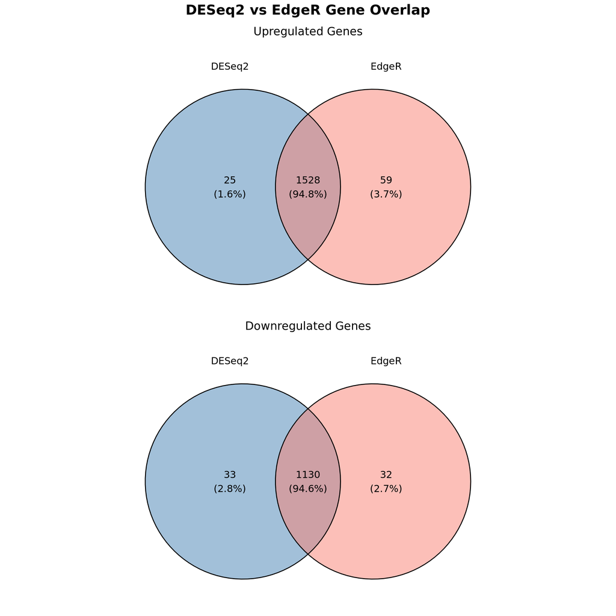

```r
# get ensembl IDs from each tool's significant gene lists
deseq2_up_ids   <- rownames(deseq2_up)
deseq2_down_ids <- rownames(deseq2_down)
edger_up_ids    <- rownames(edger_up)
edger_down_ids  <- rownames(edger_down)

# upregulated venn
venn_up <- ggvenn(
  list(DESeq2 = deseq2_up_ids, EdgeR = edger_up_ids),
  fill_color = c("steelblue", "salmon"),
  stroke_size = 0.5,
  set_name_size = 4
) +
labs(title = "Upregulated Genes") +
theme(plot.title = element_text(hjust = 0.5))

# downregulated venn
venn_down <- ggvenn(
  list(DESeq2 = deseq2_down_ids, EdgeR = edger_down_ids),
  fill_color = c("steelblue", "salmon"),
  stroke_size = 0.5,
  set_name_size = 4
) +
labs(title = "Downregulated Genes") +
theme(plot.title = element_text(hjust = 0.5))

# combine
venn_combined <- (venn_up / venn_down) +
                 plot_annotation(
                   title = "DESeq2 vs EdgeR Gene Overlap",
                   theme = theme(
                             plot.title = element_text(
                                            hjust = 0.5,
                                            size = 16,
                                            face = "bold"
                                          )
                           )
                 )

venn_combined
```

The Venn diagrams confirm **exceptionally high agreement between DESeq2 and EdgeR**.

- For **upregulated genes, 94.8% (1528) of genes are called by both tools,** with only **1.6% (25)** unique to **DESeq2** and **3.7% (59)** unique to **EdgeR**.
- For **downregulated genes, 94.6% (1130) overlap,** with **2.8% (33)** unique to **DESeq2** and **2.7% (32)** unique to **EdgeR**.

This **near-complete consensus** across two independently developed statistical methods **strongly validates the reliability of the DE gene lists**.

#### 3.4.3. Create Consensus Lists

```r
# intersect ensembl ID lists to get consensus lists
consensus_up   <- intersect(deseq2_up_ids, edger_up_ids)
consensus_down <- intersect(deseq2_down_ids, edger_down_ids)

cat("DESeq2 upregulated:     ", length(deseq2_up_ids), "\n")
```

```
DESeq2 upregulated:      1553
```

```r
cat("EdgeR upregulated:      ", length(edger_up_ids), "\n")
```

```
EdgeR upregulated:       1587
```

```r
cat("Consensus upregulated:  ", length(consensus_up), "\n\n")
```

```
Consensus upregulated:   1528
```

```r
cat("DESeq2 downregulated:   ", length(deseq2_down_ids), "\n")
```

```
DESeq2 downregulated:    1163
```

```r
cat("EdgeR downregulated:    ", length(edger_down_ids), "\n")
```

```
EdgeR downregulated:     1162
```

```r
cat("Consensus downregulated:", length(consensus_down), "\n")
```

```
Consensus downregulated: 1130
```

#### 3.4.4. Plot DE Heatmap

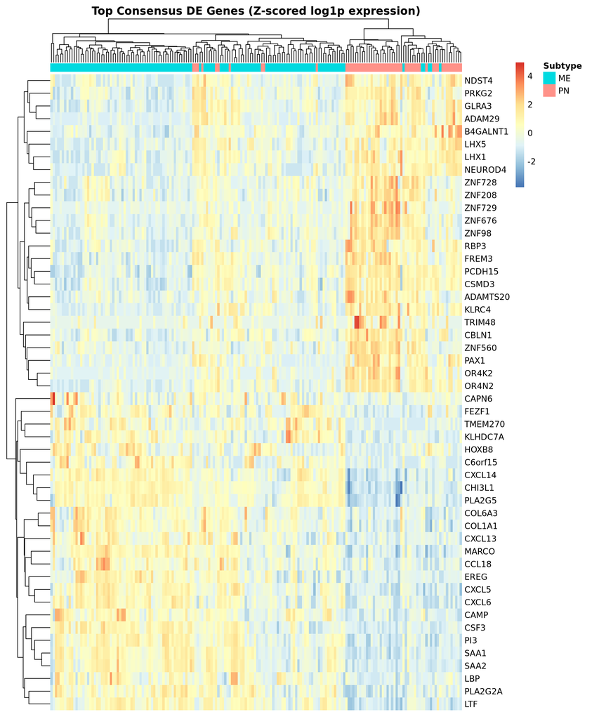

```r
# select top genes from consensus (e.g. top 25 up + top 25 down by significance)
top_up_ids   <- deseq2_up[consensus_up, ] %>% arrange(desc(log2FoldChange)) %>% head(25) %>% rownames()
top_down_ids <- deseq2_down[consensus_down, ] %>% arrange(log2FoldChange) %>% head(25) %>% rownames()
top_de_ids   <- c(top_up_ids, top_down_ids)

# extract and scale expression (log1p, z-scored per gene)
heatmap_data <- log1p(filtered_counts_matrix[top_de_ids, ])
heatmap_data <- t(scale(t(heatmap_data)))

# map ensembl IDs to gene symbols for row labels
heatmap_ids_clean <- gsub("\\..*", "", top_de_ids)
heatmap_symbols   <- bitr(heatmap_ids_clean, fromType = "ENSEMBL", toType = "SYMBOL", OrgDb = org.Hs.eg.db)
rownames(heatmap_data) <- heatmap_symbols$SYMBOL[match(heatmap_ids_clean, heatmap_symbols$ENSEMBL)]

# annotation for samples by subtype
annot_col <- data.frame(
                Subtype   = tumor_subtype_info$paper_Transcriptome.Subtype,
                row.names = colnames(filtered_counts_matrix)
              )

de_heatmap <- pheatmap(
  heatmap_data,
  annotation_col       = annot_col,
  show_colnames        = FALSE,
  annotation_names_col = FALSE,
  main                 = "Top Consensus DE Genes (Z-scored log1p expression)",
  silent               = TRUE
)$gtable

wrap_elements(de_heatmap)
```

The heatmap shows **expression of the top 50 consensus DE genes** **(25 most upregulated, 25 most downregulated in ME by log2FC)** across **all 180 samples**, **z-scored per gene** for visual comparability.

- The **upper block of genes (downregulated in ME**: **neural/synaptic genes** such as NEUROD4, LHX1, LHX5) shows **high expression** concentrated in the **PN-annotated samples**.
- The **lower block of genes (upregulated in ME**: **chemokine/inflammatory genes** such as CXCL13, CXCL14, CHI3L1, SAA1/2) shows **high expression** concentrated in **ME-annotated samples**.

## 4. Save Outputs

### 4.1. Save DE Results

```r
# save full unfiltered results for GSEA
saveRDS(as.data.frame(deseq2_results), "../04_results/05_de_analysis/01_deseq2_full_results.rds")
saveRDS(edger_results_table,           "../04_results/05_de_analysis/02_edger_full_results.rds")

cat("Saved consensus gene lists\n")
```

[output not shown]

```r
cat("Saved full DE results\n")
```

```
Saved full DE results
```

### 4.2. Save DE Plots

```r
# combined volcano plots
ggsave(
  "../03_figures/05_de_analysis/01_combined_volcano_plots.png",
  plot = combined_volcano_plot,
  width = 10,
  height = 10,
  dpi = 300
)

# DE gene list venn diagram
ggsave(
  "../03_figures/05_de_analysis/02_venn_diagram.png",
  plot = venn_combined,
  width = 10,
  height = 10,
  dpi = 300
)

png(
  "../03_figures/05_de_analysis/03_de_heatmap.png",
  width = 10,
  height = 8,
  units = "in",
  res = 300
)
grid::grid.draw(de_heatmap)
dev.off()
```

```r
cat("Saved DE plots\n")
```

```
Saved DE plots
```

## 5. Perform Sanity Checks

```r
deseq2_full_exists     <- file.exists("../04_results/05_de_analysis/01_deseq2_full_results.rds")
edger_full_exists      <- file.exists("../04_results/05_de_analysis/02_edger_full_results.rds")



combined_volcano_exists <- file.exists("../03_figures/05_de_analysis/01_combined_volcano_plots.png")
venn_exists <- file.exists("../03_figures/05_de_analysis/02_venn_diagram.png")
de_heatmap_exists <- file.exists("../03_figures/05_de_analysis/03_de_heatmap.png")



cat("DESeq2 full results saved:     ", ifelse(deseq2_full_exists,      "✓", "✗"), "\n")
```

```
DESeq2 full results saved:      ✓
```

```r
cat("EdgeR full results saved:      ", ifelse(edger_full_exists,       "✓", "✗"), "\n")
```

```
EdgeR full results saved:       ✓
```

```r
cat("Combined volcano saved:        ", ifelse(combined_volcano_exists, "✓", "✗"), "\n")
```

```
Combined volcano saved:         ✓
```

```r
cat("Venn diagram saved:            ", ifelse(venn_exists,             "✓", "✗"), "\n")
```

```
Venn diagram saved:             ✓
```

```r
cat("DE heatmap saved:              ", ifelse(de_heatmap_exists, "✓", "✗"), "\n")
```

```
DE heatmap saved:               ✓
```

```r
if (all(deseq2_full_exists, edger_full_exists,
        combined_volcano_exists, venn_exists, de_heatmap_exists)
    ) {
  cat("\nNotebook 05 complete — all outputs verified\n")
} else {
  cat("\nWARNING: One or more outputs missing\n")
}
```

```
Notebook 05 complete — all outputs verified
```